# q1

Simon, Alaa and Michael

12/17/2017

# Prep

Setting up the env and installing needed packages

```r
workspaceDir = "/Users/michaeltzach/Developer/ex3/Q1"
knitr::opts_knit$set(root.dir = workspaceDir)

if(!require(igraph)) {
  install.packages('igraph')
}
library(igraph)
set.seed(86)
```

Create helper functions

```r
colorDataGraphVerticesForGender = function(dataGraph) {
  V(dataGraph)$color = 'white'

  femaleVerticeIndexes = which(V(dataGraph)$gender=="F")
  V(dataGraph)[femaleVerticeIndexes]$color = "pink"

  maleVerticeIndexes = which(V(dataGraph)$gender=="M")
  V(dataGraph)[maleVerticeIndexes]$color = 'gray'

  return(dataGraph)
}
```

Load data

```r
edgelist = read.csv('ga_edgelist.csv', header=TRUE)
actorlist = read.csv('ga_actors.csv', header=TRUE)
```

# Grey’s Anatomy networks

## Biggest component in graph

create a graph where the actors are the vertices and the edgelist (connections) are the edges

```r
dataGraph = graph.data.frame(edgelist, directed=FALSE, vertices=actorlist)
dataGraph = colorDataGraphVerticesForGender(dataGraph)
```

Plot the graph to get the basic connections between the characters

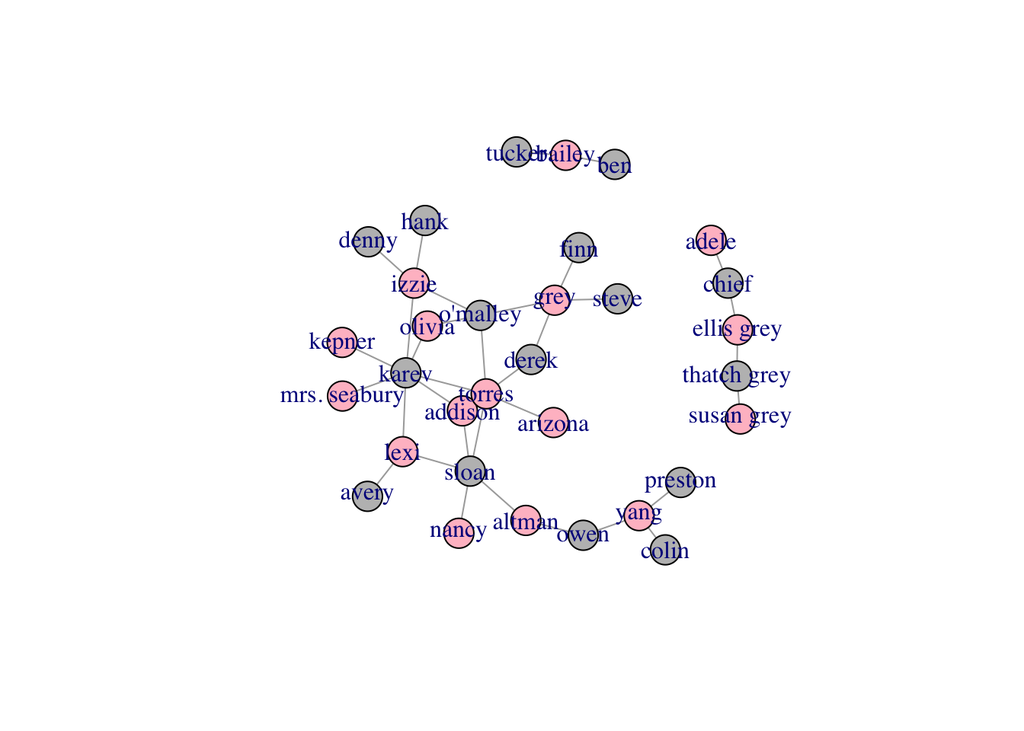

```r
plot(dataGraph)
```

Create graph that includes only the biggest component

```r
dataGraphComponents = components(dataGraph)
dataGraphComponentSizes = dataGraphComponents$csize
dataGraphComponentMemberships = dataGraphComponents$membership

biggestComponentSizeIndex = which.max(dataGraphComponentSizes)
biggestComponentVerticeIndexes = which(dataGraphComponentMemberships==biggestComponentSizeIndex)
biggestComponentVertices = V(dataGraph)[biggestComponentVerticeIndexes]

biggestComponentDataGraph = induced.subgraph(graph=dataGraph, v=biggestComponentVertices)
biggestComponentDataGraph = colorDataGraphVerticesForGender(biggestComponentDataGraph)
```

Plot the subgraph of the biggest component

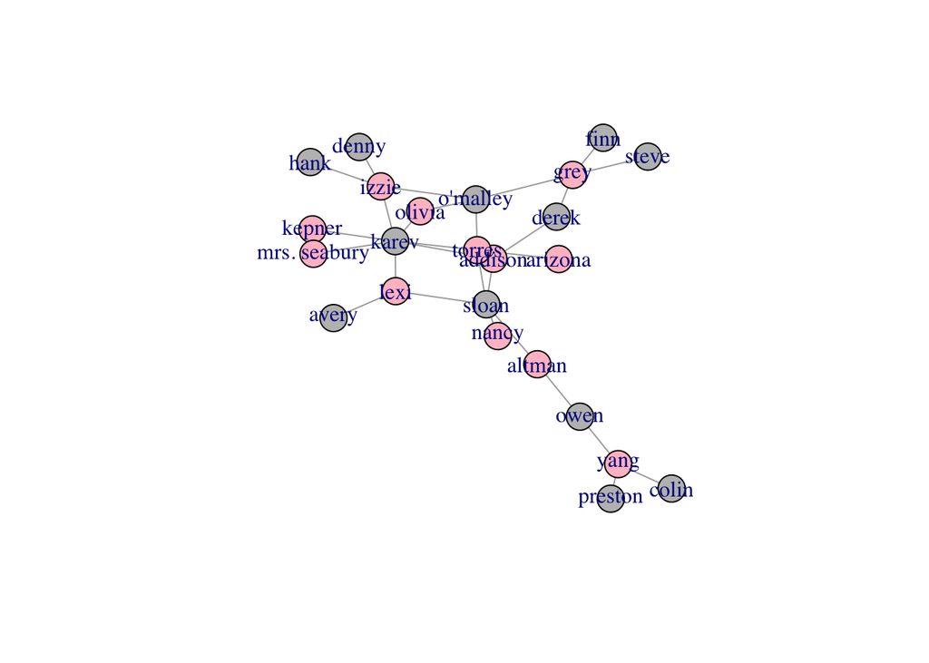

```r
plot(biggestComponentDataGraph)
```

## a.i. Checking for betweenness

Find the highest betweenness vertice

```r
betweenness = betweenness(biggestComponentDataGraph)
print(betweenness[which.max(betweenness)])
```

```
##    sloan
## 115.3667
```

Sloan has the highes betweenness

## a.ii. Checking for closeness

Find the highest closeness vertice

```r
closeness <- closeness(biggestComponentDataGraph)
print(closeness[which.max(closeness)])
```

```
##     torres
## 0.01754386
```

Torres has the highest closenesseigen_centrality

## a.iii. Checking for Eigenvector

Find the highest Eigenvector value vertice

```r
eigenvector = spectrum(biggestComponentDataGraph)$vectors
eigenvectorMaxCharacter = V(biggestComponentDataGraph)[which.max(eigenvector)]
eigenvectorMaxValue = eigenvector[which.max(eigenvector)]
print(paste("character:", eigenvectorMaxCharacter[[1]]$name, "| vector value:", eigenvectorMaxValue))
```

```
## [1] "character: karev | vector value: 0.502768787189042"
```

## b. Louvain clustering

The first algorithm that we are going to use is Louvain clustering. We will work on the data graph that we created at the beginning.

### [From the documentation of the algorithm:](http://igraph.org/r/doc/cluster_louvain.html)

*“This function implements the multi-level modularity optimization algorithm for finding community structure. It is based on the modularity measure and a hierarchial approach..”*

We will first create the cluster and then understand which character is in which grouping (what is the membership of each character)

```r
louvainCluster = cluster_louvain(dataGraph)
louvainClusterCharacterMembership = membership(louvainCluster)
```

We plot the original graph but now we paint the vertices to match the membership of the characters to the groupings in the louvain cluster

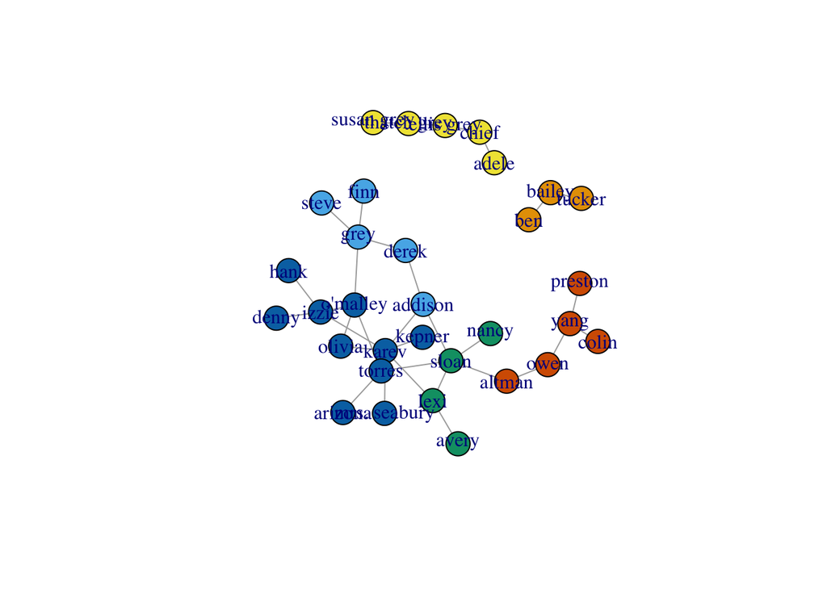

```r
plot(dataGraph, vertex.color = louvainClusterCharacterMembership)
```

Number of the communities created in the cluster

```r
louvainClusterNumberOfCommunities = length(louvainCluster)
print(paste("louvain cluster number of communities: ", louvainClusterNumberOfCommunities))
```

```
## [1] "louvain cluster number of communities:  6"
```

We get a modularity of 0.5947232

```r
louvainClusterModularity = modularity(louvainCluster)
print(paste("louvain cluster modularity: ", louvainClusterModularity))
```

```
## [1] "louvain cluster modularity:  0.594723183391003"
```

## b. Walk trap clustering

The second algorithm that we are going to use is Walktrap clustering. We will work on the data graph that we created at the beginning.

### [From the documentation of the algorithm:](http://igraph.org/r/doc/cluster_walktrap.html)

*“This function tries to find densely connected subgraphs, also called communities in a graph via random walks. The idea is that short random walks tend to stay in the same community.”*

We will first create the cluster and then understand which character is in which grouping (what is the membership of each character)

```r
walktrapCluster = cluster_walktrap(dataGraph)
walktrapClusterCharacterMembership = membership(walktrapCluster)
```

We plot the original graph but now we paint the vertices to match the membership of the characters to the groupings in the walktrap cluster

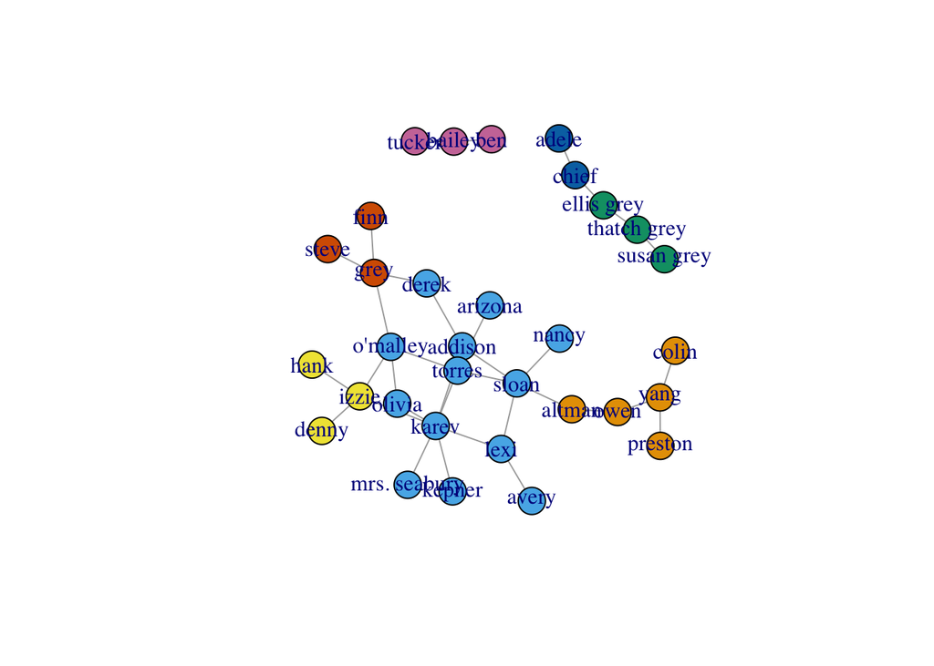

```r
plot(dataGraph, vertex.color = walktrapClusterCharacterMembership)
```

Number of the communities created in the cluster

```r
walktrapClusterNumberOfCommunities = length(walktrapCluster)
print(paste("walktrap cluster number of communities: ", walktrapClusterNumberOfCommunities))
```

```
## [1] "walktrap cluster number of communities:  7"
```

We get a modularity of 0.514705896377563

```r
walktrapClusterModularity = modularity(walktrapCluster)
print(paste("walktrap cluster modularity: ", walktrapClusterModularity))
```

```
## [1] "walktrap cluster modularity:  0.514705896377563"
```